# ONAM data examples

Additional data examples for

https://arxiv.org/abs/2407.18650

For an updated version of the ONAM package, see

https://github.com/Koehlibert/ONAM_R

## Install package:

```r
install.packages("devtools")
library(devtools)
devtools::install_github("Koehlibert/ONAM")
```

If this is the first time using keras or tensorflow in R, you need to run `keras::install_keras()`.

Load required packages for data examples:

```r
library(ONAM)
library(mlbench)
library(MASS)
library(gbm)
library(e1071)
library(caret)
library(xgboost)
library(dplyr)
```

# XGBoost for Chesapeake Bay watershed biotic integrity prediction

Load data

```r
#load data
load("BIBItrainData.RData")
bibi_data <-
  train[, c(2:5, 7, 8, 9, 10, 12, 15, 16, 17:21, 23, 24, 25, 26)] %>%
  mutate(BioregUpstream2 = as.numeric(as.factor(BioregUpstream2)))
```

Instead of the random forest model used in the manuscript, we will investigate applying a xgboost model to the original dataset.

```r
train <- bibi_data %>% dplyr::select(-CalculatedBiologicalMetricValue)
label <-
  bibi_data %>% dplyr::select(CalculatedBiologicalMetricValue) %>% unlist()

xgb_train <- xgb.DMatrix(as.matrix(train),
                         label = label)

xgb_mod <-
  xgboost(
    xgb_train,
    nrounds = 10000,
    verbose = 0
  )
```

We fit an onam model to explain the predictions.

```r
#define model formula
BIBI_formula <-
  Prediction ~ mod(Latitude) + mod(Longitude) +
  mod(BioregUpstream2) + mod(AreaSqKM) +
  mod(dep_so4_2011) + mod(elevation) +
  mod(hydrogroup_d4) + mod(percent_sandy) +
  mod(surfcoarse) + mod(deg_barr_all_local) +
  mod(upstream.total_precip) + mod(Agriculture) +
  mod(Development) + mod(Forest) + mod(Openwater) +
  mod(Barren) + mod(Grass) + mod(Woodywetland) +
  mod(Herbwetland) +
  mod(Development, elevation) +
  mod(Agriculture, elevation) +
  mod(Agriculture, Development) +
  mod(.)
#Specify model architecture in a named list where the name corresponds to the model name in the model formula
list_of_mods_BIBI <- list(mod = ONAM:::get_submodel)
categorical_features <- c("BioregUpstream2")
#Fit PHONAM model
bibi_expl_xgboost <-
  onam(
    formula,
    list_of_deep_models,
    bibi_data,
    model = xgb_mod,
    model_data = xgb_train,
    categorical_features = categorical_features,
    n_ensemble = 20,
    epochs = 1000,
    verbose = 0,
    progresstext = TRUE
  )
summary(bibi_expl_xgboost)
#generate prediction object for saving
bibi_expl_xg_res <- predict(bibi_expl_xgboost)
saveRDS(bibi_expl_xg_res, "BIBIEval_xgb.RDS")
```

## Model visualization

[output not shown]

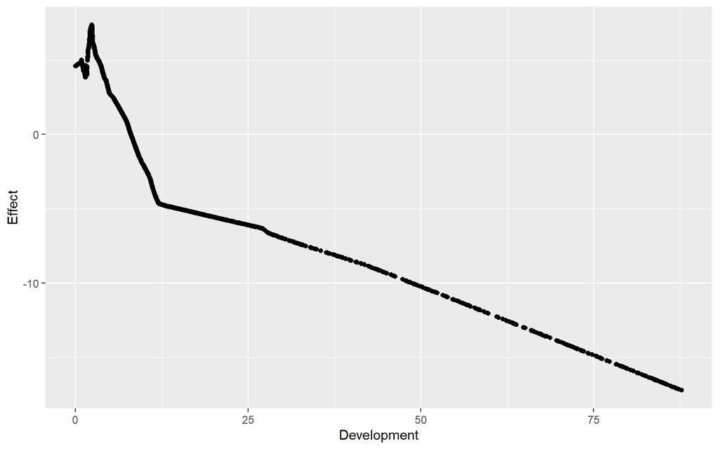

```r
BIBI_Res <- readRDS("BIBIEval_xgb.RDS")

plot_main_effect(BIBI_Res, "Development")
```

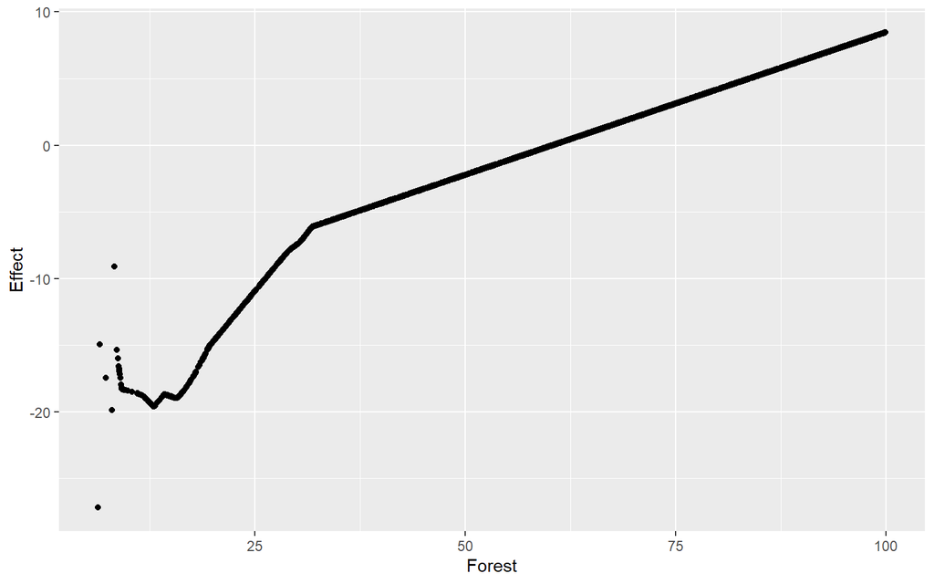

```r
plot_main_effect(BIBI_Res, "Forest")
```

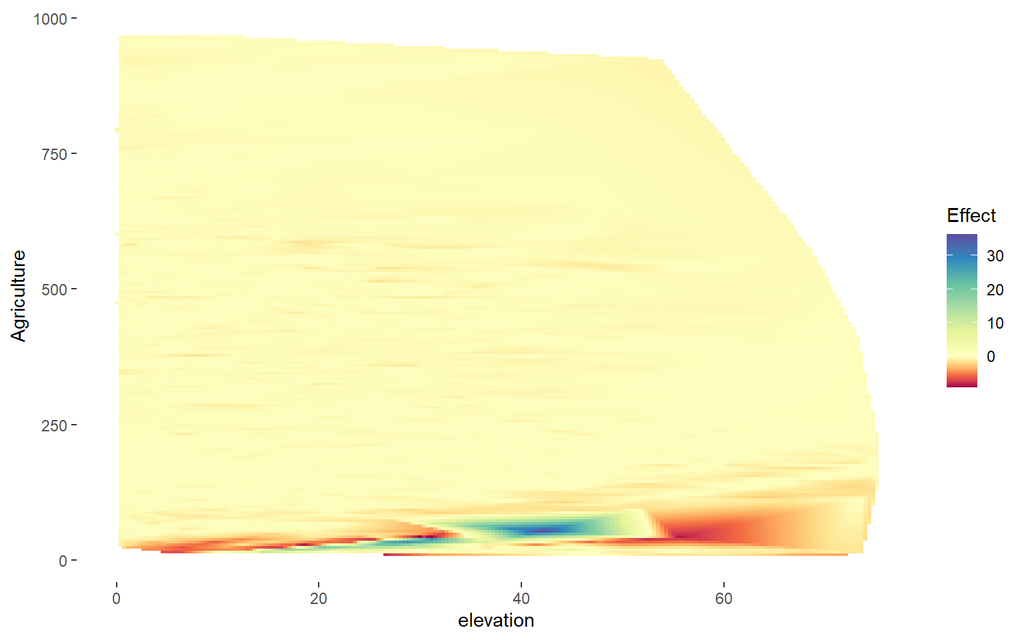

```r
plot_inter_effect(BIBI_Res, "Agriculture", "elevation", interpolate = TRUE)
```

# Binary classification gradient boosting machine for diabetes prediction

The Pima Indians Diabetes Database is a dataset from the Indian National Institute of Diabetes and Digestive and Kidney Dieseases. https://www.mdpi.com/2076-3417/9/21/4604

```r
data(PimaIndiansDiabetes)
diabetes_data <- PimaIndiansDiabetes %>%
  mutate(diabetes = ifelse(diabetes == "pos", 1, 0)) %>%
  mutate(across(!diabetes, as.numeric)) %>%
  filter(mass > 0)

head(diabetes_data)
```

```
##   pregnant glucose pressure triceps insulin mass pedigree age diabetes
## 1        6     148       72      35       0 33.6    0.627  50        1
## 2        1      85       66      29       0 26.6    0.351  31        0
## 3        8     183       64       0       0 23.3    0.672  32        1
## 4        1      89       66      23      94 28.1    0.167  21        0
## 5        0     137       40      35     168 43.1    2.288  33        1
## 6        5     116       74       0       0 25.6    0.201  30        0
```

It consists of 757 instances of multiple medical features and the diabetes status of each observation. There are 266 diabetes cases and 491 controls in the dataset.

We demonstrate how to use ONAM to explain the prediction of a gradient boosting machine for prediction of the diabetes status.

First, we fit a gradient boosting machine for prediction of diabtetes probability.

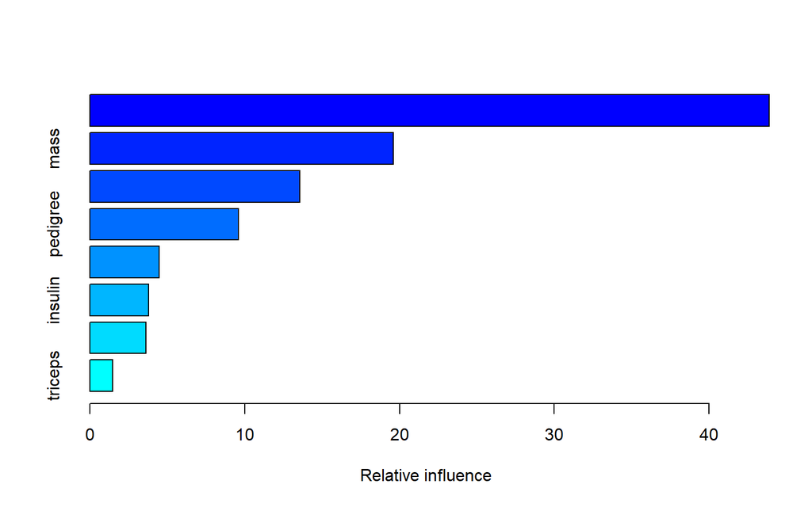

```
##               var   rel.inf
## glucose   glucose 43.874608
## mass         mass 19.593602
## age           age 13.557773
## pedigree pedigree  9.600457
## pregnant pregnant  4.471648
## insulin   insulin  3.810184
## pressure pressure  3.622608
## triceps   triceps  1.469120
```

```r
# Train the GBM model (binary classification)
gbm_model <- gbm(diabetes ~ .,
                 data = diabetes_data,
                 distribution = "bernoulli",
                 n.trees = 500,
                 interaction.depth = 3,
                 shrinkage = 0.01,
                 cv.folds = 5)
# Print model summary
summary(gbm_model)
```

Model performance:

```r
predicted_status <- predict(gbm_model, diabetes_data, n.trees = 500)
caret::confusionMatrix(factor(as.numeric(predicted_status > 0.5)), factor(diabetes_data$diabetes))
```

```
## Confusion Matrix and Statistics
##
##           Reference
## Prediction   0   1
##          0 466 127
##          1  25 139
##
##                Accuracy : 0.7992
##                  95% CI : (0.7689, 0.8272)
##     No Information Rate : 0.6486
##     P-Value [Acc > NIR] : < 2.2e-16
##
##                   Kappa : 0.5171
##
##  Mcnemar's Test P-Value : 2.565e-16
##
##             Sensitivity : 0.9491
##             Specificity : 0.5226
##          Pos Pred Value : 0.7858
##          Neg Pred Value : 0.8476
##              Prevalence : 0.6486
##          Detection Rate : 0.6156
##    Detection Prevalence : 0.7834
##       Balanced Accuracy : 0.7358
##
##        'Positive' Class : 0
##
```

## Fit ONAM model on gbm data

```r
Diabetes_formula <- diabetes ~ mod(glucose) + mod(insulin) +
  mod(pregnant) + mod(pressure) + mod(triceps) + mod(pedigree) +
  mod(mass) + mod(age) + mod(glucose, insulin) + mod(age, mass) +
  mod(.)
list_of_mods_Diabetes <- list(mod = ONAM:::get_submodel)
gbm_expl <- onam(
  Diabetes_formula,
  list_of_deep_models_Diabetes,
  diabetes_data,
  gbm_model,
  prediction_function = function(model, data) {
    predict(model, data, n.trees = 500, type = "response")
  },
  target = "binary",
  n_ensemble = 20,
  progresstext = TRUE,
  epochs = 500,
  verbose = 0
)

#generate prediction object for saving
gbm_res <- predict(gbm_expl)
saveRDS(gbm_res, "gbm_res.RDS")
```

[output not shown]

### Example of effect plots

The shown effects are on the logit scale.

A higher plasma glucose concentration is associated with a higher risk of diabetes:

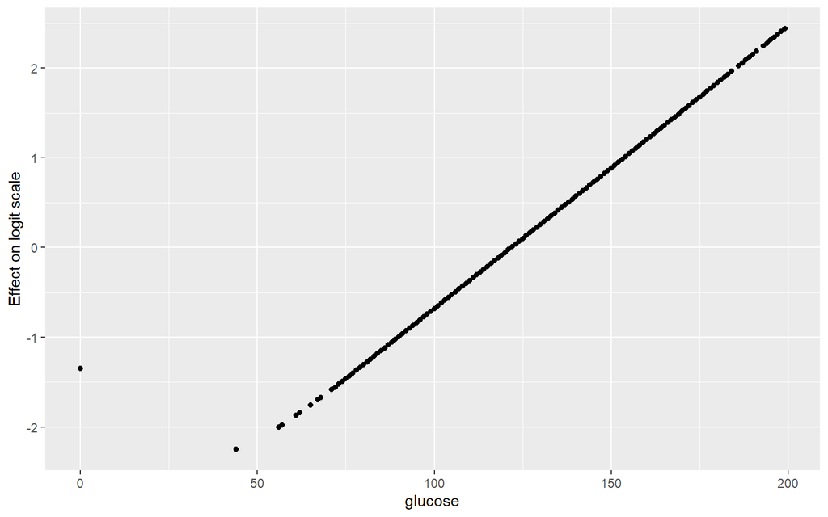

```r
plot_main_effect(gbm_res, "glucose")
```

A higher BMI is associated with a higher risk of diabetes, but the increase is lower in younger people.

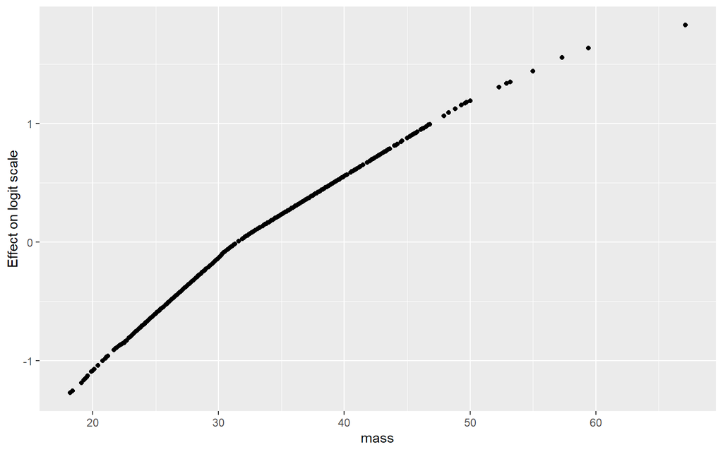

```r
plot_main_effect(gbm_res, "mass")
```

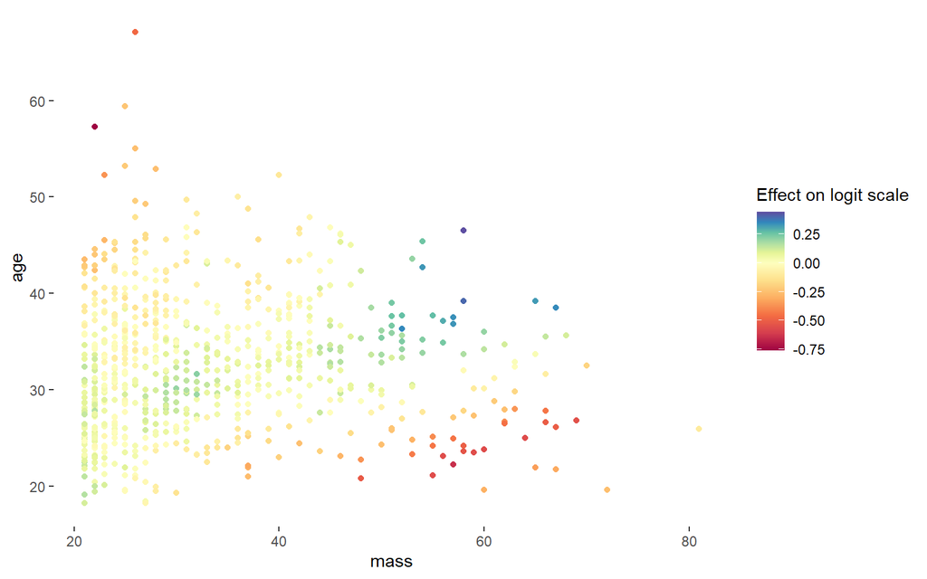

```r
plot_inter_effect(gbm_res, "age", "mass", interpolate = FALSE)
```

# Prediction of Boston housing prices using xgboost

The Boston dataset contains data collected by the US Census Service on socioecological features of housing in Boston, MA. It contains 13 features along with the median value of owner-occupied homes, which will be the outcome in this section.

```r
data("Boston")

head(Boston)
```

```
##      crim zn indus chas   nox    rm  age    dis rad tax ptratio  black lstat
## 1 0.00632 18  2.31    0 0.538 6.575 65.2 4.0900   1 296    15.3 396.90  4.98
## 2 0.02731  0  7.07    0 0.469 6.421 78.9 4.9671   2 242    17.8 396.90  9.14
## 3 0.02729  0  7.07    0 0.469 7.185 61.1 4.9671   2 242    17.8 392.83  4.03
## 4 0.03237  0  2.18    0 0.458 6.998 45.8 6.0622   3 222    18.7 394.63  2.94
## 5 0.06905  0  2.18    0 0.458 7.147 54.2 6.0622   3 222    18.7 396.90  5.33
## 6 0.02985  0  2.18    0 0.458 6.430 58.7 6.0622   3 222    18.7 394.12  5.21
##   medv
## 1 24.0
## 2 21.6
## 3 34.7
## 4 33.4
## 5 36.2
## 6 28.7
```

The dataset contains information 506 towns. We use xgboost to fit a prediction model for median housing prices per town.

```r
train_Boston <- Boston %>% dplyr::select(-medv)
label_Boston <- Boston %>% dplyr::select(medv) %>% unlist()

xgb_train_Boston <- xgb.DMatrix(as.matrix(train_Boston),
                                   label = label_Boston)

xgb_mod <-
  xgboost(
    xgb_train_Boston,
    nrounds = 10000,
    verbose = 0,
    objective = "reg:squarederror",
    eval_metric = "rmse"
  )
summary(xgb_mod)
```

```
##                Length  Class              Mode
## handle               1 xgb.Booster.handle externalptr
## raw            7318563 -none-             raw
## niter                1 -none-             numeric
## evaluation_log       2 data.table         list
## call                15 -none-             call
## params               3 -none-             list
## callbacks            1 -none-             list
## feature_names       13 -none-             character
## nfeatures            1 -none-             numeric
```

```r
preds <- predict(xgb_mod, xgb_train_Boston)
pricing_cor <- cor(preds, Boston$medv)
```

Correlation between housing prices and predictions: 1

## Fit ONAM model on xgboost data

We explain the xgboost using the orthogonal additive model framework:

```r
Boston_formula <-
  medv ~ mod(crim) + mod(zn) + mod(indus) + mod(chas) +
  mod(nox) + mod(rm) + mod(age) + mod(dis) + mod(rad) +
  mod(tax) + mod(ptratio) + mod(black) + mod(lstat) +
  mod(crim, dis) + mod(rm, age) + mod(zn, indus) +
  mod(.)

list_of_deep_models_Boston <- list(mod = ONAM:::get_submodel)

categorical_features <- c("chas")

xgb_expl <-
  onam(
    Boston_formula,
    list_of_deep_models_Boston,
    Boston,
    # target = "binary",
    model = xgb_mod,
    model_data = xgb_train_Boston,
    categorical_features = categorical_features,
    n_ensemble = 20,
    epochs = 1000,
    progresstext = TRUE,
    verbose = 0
  )

xgb_res <- predict(xgb_expl)
saveRDS(xgb_res, "xgb_res.RDS")
```

```
##
## Call:
## onam(formula = Boston_formula, list_of_deep_models = list_of_deep_models_Boston,
##     data = Boston, model = xgb_mod, model_data = xgb_train_Boston,
##     categorical_features = categorical_features, n_ensemble = 20,
##     epochs = 1000, progresstext = TRUE, verbose = 0)
##
## Correlation of model prediction with outcome variable: 0.9942
## Number of ensemble members:  20
## I_1: 0.924; I_2:  0.0415
## Degree of interpretability: 0.9656
```

### Examples of effect plots

Higher crime rate is associated with lower housing prices

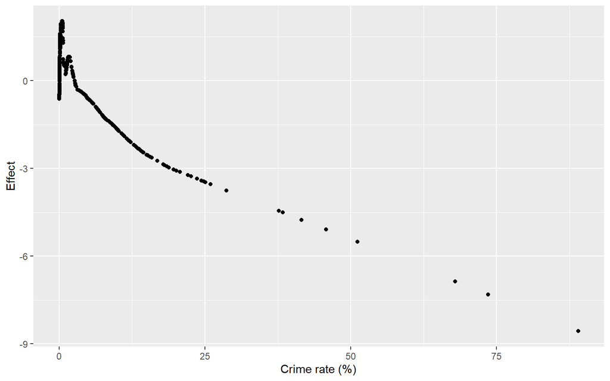

```r
plot_main_effect(xgb_res, "crim") + xlab("Crime rate (%)")
```

Lower number of rooms is associated with lower housing prices, but less so in (areas with) older houses.

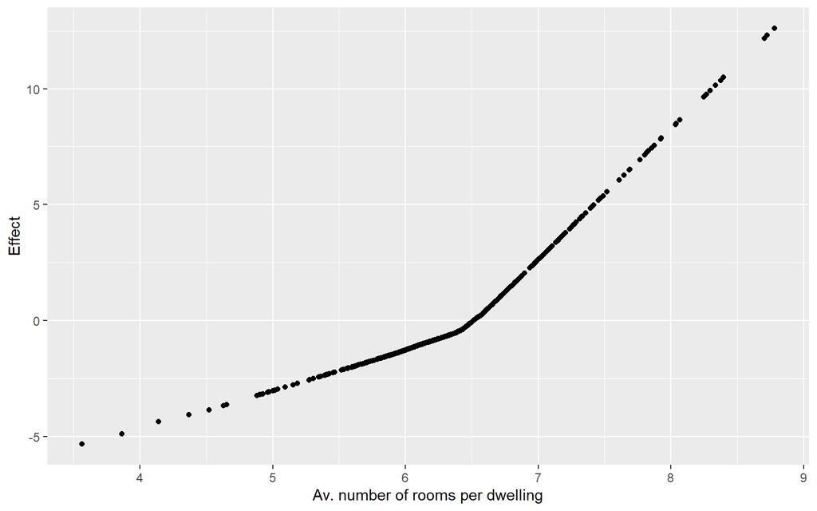

```r
plot_main_effect(xgb_res, "rm") + xlab("Av. number of rooms per dwelling")
```

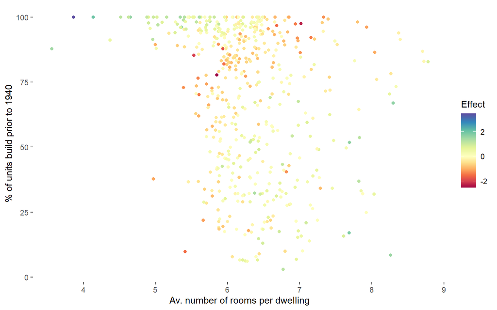

```r
plot_inter_effect(xgb_res, "rm", "age") + xlab("Av. number of rooms per dwelling") + ylab("% of units build prior to 1940")
```